# data_mining_project

```python
pip install imbalanced-learn
```

```python
pip install xgboost
```

```python
#importing necessary libraries
import pandas as pd
import numpy as np
import matplotlib.pyplot as plt
import seaborn as sns
import re
import nltk
from nltk.corpus import stopwords
from nltk.tokenize import word_tokenize
from nltk.stem import WordNetLemmatizer
from sklearn.preprocessing import OneHotEncoder
from sklearn.preprocessing import LabelEncoder
from textblob import TextBlob
from sklearn.preprocessing import StandardScaler
from statsmodels.stats.outliers_influence import variance_inflation_factor
from sklearn.model_selection import train_test_split
from sklearn.tree import DecisionTreeClassifier
from sklearn.model_selection import GridSearchCV
from sklearn.tree import plot_tree
from sklearn.metrics import accuracy_score, classification_report, confusion_matrix
from imblearn.over_sampling import SMOTE
from sklearn.tree import DecisionTreeClassifier
from sklearn.ensemble import GradientBoostingClassifier
from sklearn.ensemble import RandomForestClassifier
from sklearn.model_selection import cross_val_score
from sklearn.model_selection import StratifiedKFold
from imblearn.pipeline import Pipeline
import xgboost as xgb
import time
```

```python
#loading the dataset into a pandas dataframe
airbnb_data = pd.read_csv('airbnb_berlin.csv')

#showing the first few rows
airbnb_data.head()
```

|  | index | Review ID | review_date | Reviewer ID | Reviewer Name | Comments | Listing ID | Listing URL | Listing Name | Host ID | ... | Last Review | Overall Rating | Accuracy Rating | Cleanliness Rating | Checkin Rating | Communication Rating | Location Rating | Value Rating | Instant Bookable | Business Travel Ready |
| --- | --- | --- | --- | --- | --- | --- | --- | --- | --- | --- | --- | --- | --- | --- | --- | --- | --- | --- | --- | --- | --- |
| 0 | 0 | 58660447.0 | 01-03-16 | 14876562.0 | Dennis | Very nice, clean appartement! Josh was really ... | 10002699 | https://www.airbnb.com/rooms/10002699 | Trendy and peaceful KreuzkÃ¶lln | 44696672 | ... | 01-03-16 | 100.0 | 8.0 | 10.0 | 6.0 | 10.0 | 10.0 | 10.0 | f | f |
| 1 | 1 | NaN | NaN | NaN | NaN | NaN | 10002922 | https://www.airbnb.com/rooms/10002922 | Sehr zentrale Wohnung in Berlin | 45848709 | ... | NaN | NaN | NaN | NaN | NaN | NaN | NaN | NaN | f | f |
| 2 | 2 | 58663795.0 | 01-03-16 | 49367757.0 | Andreea | Aki is really nice and friendly. We had an ama... | 10006647 | https://www.airbnb.com/rooms/10006647 | Very central and very quite | 40791092 | ... | 02-12-17 | 92.0 | 9.0 | 8.0 | 9.0 | 10.0 | 10.0 | 9.0 | f | f |
| 3 | 3 | 59003619.0 | 01-05-16 | 46694292.0 | Sasha | Aki is a very nice dude with a clean place in ... | 10006647 | https://www.airbnb.com/rooms/10006647 | Very central and very quite | 40791092 | ... | 02-12-17 | 92.0 | 9.0 | 8.0 | 9.0 | 10.0 | 10.0 | 9.0 | f | f |
| 4 | 4 | 66845661.0 | 03-25-16 | 54542819.0 | Yohana | Aki's place was easy to find and located in th... | 10006647 | https://www.airbnb.com/rooms/10006647 | Very central and very quite | 40791092 | ... | 02-12-17 | 92.0 | 9.0 | 8.0 | 9.0 | 10.0 | 10.0 | 9.0 | f | f |

5 rows × 47 columns

```python
#programmatic assessment of dataset
airbnb_data.info()
```

```
<class 'pandas.core.frame.DataFrame'>
RangeIndex: 456961 entries, 0 to 456960
Data columns (total 47 columns):
 #   Column                 Non-Null Count   Dtype
---  ------                 --------------   -----
 0   index                  456961 non-null  int64
 1   Review ID              452805 non-null  float64
 2   review_date            452805 non-null  object
 3   Reviewer ID            452805 non-null  float64
 4   Reviewer Name          452805 non-null  object
 5   Comments               452597 non-null  object
 6   Listing ID             456961 non-null  int64
 7   Listing URL            456961 non-null  object
 8   Listing Name           456756 non-null  object
 9   Host ID                456961 non-null  int64
```

[output cut: 39 more lines]

### DATA CLEANING AND PREPROCESSING

```python
#checking for missing values
missing_values = airbnb_data.isnull().sum()

#checking data types
data_types = airbnb_data.dtypes

#summary of missing values and data types
missing_values_summary = pd.DataFrame({'Missing Values': missing_values, 'Data Type': data_types})
missing_values_summary.sort_values(by='Missing Values', ascending=False)
```

|  | Missing Values | Data Type |
| --- | --- | --- |
| Square Feet | 428286 | float64 |
| Host Response Rate | 58767 | object |
| Host Response Time | 58767 | object |
| Postal Code | 7703 | object |
| Value Rating | 4776 | float64 |
| Location Rating | 4775 | float64 |
| Checkin Rating | 4773 | float64 |
| Communication Rating | 4756 | float64 |
| Accuracy Rating | 4752 | float64 |
| Cleanliness Rating | 4750 | float64 |
| Overall Rating | 4719 | float64 |
| Comments | 4364 | object |
| First Review | 4156 | object |
| Review ID | 4156 | float64 |
| Last Review | 4156 | object |
| review_date | 4156 | object |
| Reviewer ID | 4156 | float64 |
| Reviewer Name | 4156 | object |
| Bathrooms | 943 | float64 |
| Bedrooms | 717 | float64 |
| Listing Name | 205 | object |
| Beds | 90 | float64 |
| Is Superhost | 48 | object |
| Host Since | 48 | object |
| Host Name | 48 | object |
| City | 33 | object |
| Guests Included | 0 | int64 |
| Instant Bookable | 0 | object |
| Min Nights | 0 | int64 |
| Reviews | 0 | int64 |
| Price | 0 | object |
| index | 0 | int64 |
| Longitude | 0 | float64 |
| Accomodates | 0 | int64 |
| Room Type | 0 | object |
| Property Type | 0 | object |
| Is Exact Location | 0 | object |
| Latitude | 0 | float64 |
| Country | 0 | object |
| Country Code | 0 | object |
| Neighborhood Group | 0 | object |
| neighbourhood | 0 | object |
| Host URL | 0 | object |
| Host ID | 0 | int64 |
| Listing URL | 0 | object |
| Listing ID | 0 | int64 |
| Business Travel Ready | 0 | object |

```python
#checking for duplicate rows
duplicates = airbnb_data.duplicated().sum()
duplicates
```

```
0
```

```python
#dropping columns that might not be relevant for analyzing customer satisfaction, more columns might be added upon further investigation of the dataset
columns_to_drop = ['Host URL', 'Listing URL', 'Country', 'Country Code']
airbnb_data = airbnb_data.drop(columns=columns_to_drop)
```

```python
#converting 'Price' to numeric, handling non-numeric characters
airbnb_data['Price'] = pd.to_numeric(airbnb_data['Price'], errors='coerce')
```

```python
#ensuring that prices are non-negative
airbnb_data = airbnb_data[airbnb_data['Price'] >= 0]
```

```python
#checking the count and descriptive statistics of the 'Price' column
num_rows_price = airbnb_data['Price'].shape[0]
price_description  = airbnb_data['Price'].describe()
```

```python
num_rows_price, price_description
```

```
(456719,
 count    456719.000000
 mean         67.660621
 std          51.587050
 min           0.000000
 25%          37.000000
 50%          53.000000
 75%          80.000000
 max         999.000000
 Name: Price, dtype: float64)
```

```python
#contextual analysis of zero-priced listings
#filtering the dataset for zero-priced listings
zero_priced_listings = airbnb_data[airbnb_data['Price'] == 0]
rating_columns = ['Overall Rating', 'Accuracy Rating', 'Cleanliness Rating',
                  'Checkin Rating', 'Communication Rating', 'Location Rating',
                  'Value Rating']

#analyzing common characteristics of these listings
zero_price_common_chars = {
    'Number of Zero Priced Listings': zero_priced_listings.shape[0],
    'Unique Hosts': zero_priced_listings['Host ID'].nunique(),
    'Common Neighborhoods': zero_priced_listings['neighbourhood'].value_counts().head(5),
    'Common Property Types': zero_priced_listings['Property Type'].value_counts().head(5),
    'Average Ratings': zero_priced_listings[rating_columns].mean()
}
zero_price_common_chars
```

```
{'Number of Zero Priced Listings': 131,
 'Unique Hosts': 6,
 'Common Neighborhoods': Mitte             86
 Marienfelde       33
 Marzahn            9
 Friedrichshain     2
 Kreuzberg          1
 Name: neighbourhood, dtype: int64,
 'Common Property Types': Apartment             89
 House                 33
 Serviced apartment     9
 Name: Property Type, dtype: int64,
 'Average Ratings': Overall Rating          91.875969
 Accuracy Rating          9.263566
 Cleanliness Rating       9.077519
 Checkin Rating           9.333333
 Communication Rating     9.333333
 Location Rating          9.604651
 Value Rating             9.193798
 dtype: float64}
```

We can infer that the presence of zero-priced listings are not errors, and they represent special promotions or peculiar hosting situations. The high average ratings across all rating categories indicate positive guest experiences, which could be influenced by the zero pricing. We have chosen to include this in the analysis based on these findings as they represent comprehensive analysis of customer satisfaction, and are also unique yet valid scenarios within the Airbnb market in Berlin.

```python
#dropping missing values in the ratings column
airbnb_data = airbnb_data.dropna(subset=rating_columns)
```

```python
#checking the summary stats of the ratings column
airbnb_data[rating_columns].describe()
```

|  | Overall Rating | Accuracy Rating | Cleanliness Rating | Checkin Rating | Communication Rating | Location Rating | Value Rating |
| --- | --- | --- | --- | --- | --- | --- | --- |
| count | 451952.000000 | 451952.000000 | 451952.000000 | 451952.000000 | 451952.000000 | 451952.000000 | 451952.000000 |
| mean | 94.571335 | 9.769347 | 9.502896 | 9.805561 | 9.806581 | 9.639112 | 9.426829 |
| std | 4.382681 | 0.472034 | 0.681963 | 0.437338 | 0.442288 | 0.528119 | 0.576149 |
| min | 20.000000 | 2.000000 | 2.000000 | 2.000000 | 2.000000 | 2.000000 | 2.000000 |
| 25% | 92.000000 | 10.000000 | 9.000000 | 10.000000 | 10.000000 | 9.000000 | 9.000000 |
| 50% | 96.000000 | 10.000000 | 10.000000 | 10.000000 | 10.000000 | 10.000000 | 9.000000 |
| 75% | 98.000000 | 10.000000 | 10.000000 | 10.000000 | 10.000000 | 10.000000 | 10.000000 |
| max | 100.000000 | 10.000000 | 10.000000 | 10.000000 | 10.000000 | 10.000000 | 10.000000 |

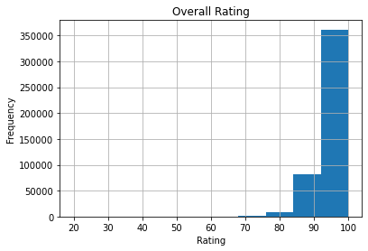

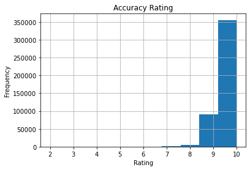

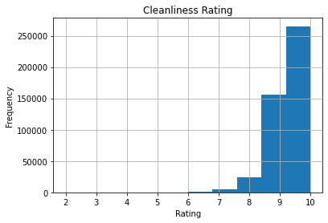

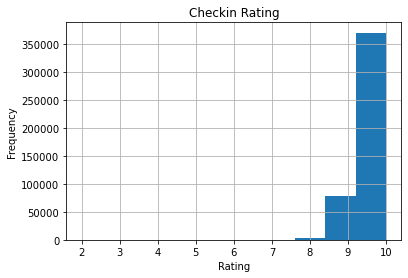

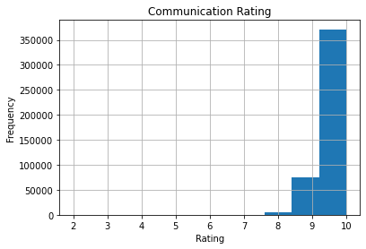

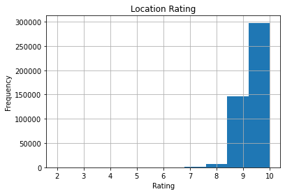

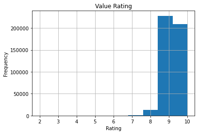

```python
#creating histograms for further analysis of the ratings columns
for column in rating_columns:
    airbnb_data[column].hist()
    plt.title(column)
    plt.xlabel('Rating')
    plt.ylabel('Frequency')
    plt.show()
```

```python
#defining percentiles for categorizing ratings
high_rating_threshold = airbnb_data[rating_columns].quantile(0.75)
medium_rating_threshold = airbnb_data[rating_columns].quantile(0.25)

#creating a function to categorize ratings
def categorize_ratings(row, high_threshold, medium_threshold):
    if row > high_threshold:
        return 'High'
    elif row < medium_threshold:
        return 'Low'
    else:
        return 'Medium'

#applying the categorization to each ratings column
categorized_ratings = airbnb_data[rating_columns].apply(lambda x: x.apply(categorize_ratings,
                                                                                  args=(high_rating_threshold[x.name],
                                                                                        medium_rating_threshold[x.name])))

#displaying the first few rows of the categorized ratings
categorized_ratings.head()
```

|  | Overall Rating | Accuracy Rating | Cleanliness Rating | Checkin Rating | Communication Rating | Location Rating | Value Rating |
| --- | --- | --- | --- | --- | --- | --- | --- |
| 0 | High | Low | Medium | Low | Medium | Medium | Medium |
| 2 | Medium | Low | Low | Low | Medium | Medium | Medium |
| 3 | Medium | Low | Low | Low | Medium | Medium | Medium |
| 4 | Medium | Low | Low | Low | Medium | Medium | Medium |
| 5 | Medium | Low | Low | Low | Medium | Medium | Medium |

```python
medium_rating_threshold
```

```
Overall Rating          92.0
Accuracy Rating         10.0
Cleanliness Rating       9.0
Checkin Rating          10.0
Communication Rating    10.0
Location Rating          9.0
Value Rating             9.0
Name: 0.25, dtype: float64
```

From these observed values we can see how our contextual analysis of the zero priced listings are further validated as the ratings are genrally on the higher side

```python
#downloading necessary NLTK resources
nltk.download('punkt')
nltk.download('stopwords')
nltk.download('wordnet')
```

```
True
```

```python
nltk.download('omw-1.4')
```

```
True
```

```python
#text data preprocessing
def preprocess_text(text):
    #checking if the text is not a string (e.g., NaN or None)
    if not isinstance(text, str):
        return ""

    #removing special characters
    text = re.sub(r'[^a-zA-Z\s]', '', text, re.I|re.A)

    #normalizing text to lowercase
    text = text.lower()

    #tokenize text
    tokens = word_tokenize(text)

    #remove stopwords
    stop_words = set(stopwords.words('english'))
    filtered_tokens = [token for token in tokens if token not in stop_words]

    #lemmatization
    lemmatizer = WordNetLemmatizer()
    lemmatized_text = [lemmatizer.lemmatize(token) for token in filtered_tokens]

    return ' '.join(lemmatized_text)
```

```python
#applying text preprocessing to the Comments column
airbnb_data['Processed_Comments'] = airbnb_data['Comments'].apply(preprocess_text)
airbnb_data['Processed_Comments'].head(10)
```

```
0     nice clean appartement josh really great altou...
2     aki really nice friendly amazing time berlin r...
3     aki nice dude clean place good location proble...
4     akis place easy find located heart berlin room...
5             wait min aki arrive fine location amazing
6     great room comfortable clean aki roomate nice ...
7     aki really friendly available giving u advice ...
8     aki e sin duda el mejor host q uno puede tener...
9     meer aki meet fabin kind made u feel like home...
10    aki awesome host berlin got along well since c...
Name: Processed_Comments, dtype: object
```

```python
airbnb_data.info()
```

```
<class 'pandas.core.frame.DataFrame'>
Int64Index: 451952 entries, 0 to 456960
Data columns (total 44 columns):
 #   Column                 Non-Null Count   Dtype
---  ------                 --------------   -----
 0   index                  451952 non-null  int64
 1   Review ID              451950 non-null  float64
 2   review_date            451950 non-null  object
 3   Reviewer ID            451950 non-null  float64
 4   Reviewer Name          451950 non-null  object
 5   Comments               451742 non-null  object
 6   Listing ID             451952 non-null  int64
 7   Listing Name           451773 non-null  object
 8   Host ID                451952 non-null  int64
 9   Host Name              451917 non-null  object
```

[output cut: 36 more lines]

```python
columns_with_missing_values = ['Property Type', 'Room Type', 'Host Response Time',
                               'Is Superhost', 'Is Exact Location', 'Processed_Comments']

#dropping rows with missing values in the specified columns
airbnb_data = airbnb_data.dropna(subset=columns_with_missing_values)
```

We will use one hot encoder for the property type and room type columns because they do not have too many categories and are also nominal while for the neighborhood column we would be using the label encoder beacause of the amount of categories in the variable

```python
#one hot encoder
one_hot_encoder = OneHotEncoder(sparse=False)
one_hot_encoded = one_hot_encoder.fit_transform(airbnb_data[['Property Type', 'Room Type','Host Response Rate', 'Is Superhost']])

#converting one-hot encoded data to a DataFrame
columns_one_hot_encoded = one_hot_encoder.get_feature_names_out(['Property Type', 'Room Type', 'Host Response Rate', 'Is Superhost'])
df_one_hot_encoded = pd.DataFrame(one_hot_encoded, columns=columns_one_hot_encoded)

#combining the encoded columns with the original dataset
airbnb_data = airbnb_data.join(df_one_hot_encoded)
```

```python
#label encoder
label_encoder = LabelEncoder()
airbnb_data['neighbourhood_encoded'] = label_encoder.fit_transform(airbnb_data['neighbourhood'])
```

```python
#combining the one-hot encoded columns with the original dataset
airbnb_data_encoded = airbnb_data.join(df_one_hot_encoded, lsuffix='_left', rsuffix='_right')

#display the first few rows of the new dataset
airbnb_data_encoded.head()
```

|  | index | Review ID | review_date | Reviewer ID | Reviewer Name | Comments | Listing ID | Listing Name | Host ID | Host Name | ... | Host Response Rate_92%_right | Host Response Rate_93%_right | Host Response Rate_94%_right | Host Response Rate_95%_right | Host Response Rate_96%_right | Host Response Rate_97%_right | Host Response Rate_98%_right | Host Response Rate_99%_right | Is Superhost_f_right | Is Superhost_t_right |
| --- | --- | --- | --- | --- | --- | --- | --- | --- | --- | --- | --- | --- | --- | --- | --- | --- | --- | --- | --- | --- | --- |
| 2 | 2 | 58663795.0 | 01-03-16 | 49367757.0 | Andreea | Aki is really nice and friendly. We had an ama... | 10006647 | Very central and very quite | 40791092 | Arkadij | ... | 0.0 | 0.0 | 0.0 | 0.0 | 0.0 | 0.0 | 0.0 | 0.0 | 1.0 | 0.0 |
| 3 | 3 | 59003619.0 | 01-05-16 | 46694292.0 | Sasha | Aki is a very nice dude with a clean place in ... | 10006647 | Very central and very quite | 40791092 | Arkadij | ... | 0.0 | 0.0 | 0.0 | 0.0 | 0.0 | 0.0 | 0.0 | 0.0 | 1.0 | 0.0 |
| 4 | 4 | 66845661.0 | 03-25-16 | 54542819.0 | Yohana | Aki's place was easy to find and located in th... | 10006647 | Very central and very quite | 40791092 | Arkadij | ... | 0.0 | 0.0 | 0.0 | 0.0 | 0.0 | 0.0 | 0.0 | 0.0 | 1.0 | 0.0 |
| 5 | 5 | 67969785.0 | 04-01-16 | 35352843.0 | Mitchell | We had to wait 30mins for Aki to arrive but ot... | 10006647 | Very central and very quite | 40791092 | Arkadij | ... | 0.0 | 0.0 | 0.0 | 0.0 | 0.0 | 0.0 | 0.0 | 0.0 | 1.0 | 0.0 |
| 6 | 6 | 68816282.0 | 04-06-16 | 48006291.0 | Cindy | Great room, very comfortable and clean. Aki an... | 10006647 | Very central and very quite | 40791092 | Arkadij | ... | 0.0 | 0.0 | 0.0 | 0.0 | 0.0 | 0.0 | 0.0 | 0.0 | 1.0 | 0.0 |

5 rows × 261 columns

```python
#saving progress
#airbnb_data.to_csv('airbnb_data_cleaned.csv', index=False)
#airbnb_data_encoded.to_csv('airbnb_data_encoded.csv', index=False)
```

### EXPLORATORY DATA ANALYSIS

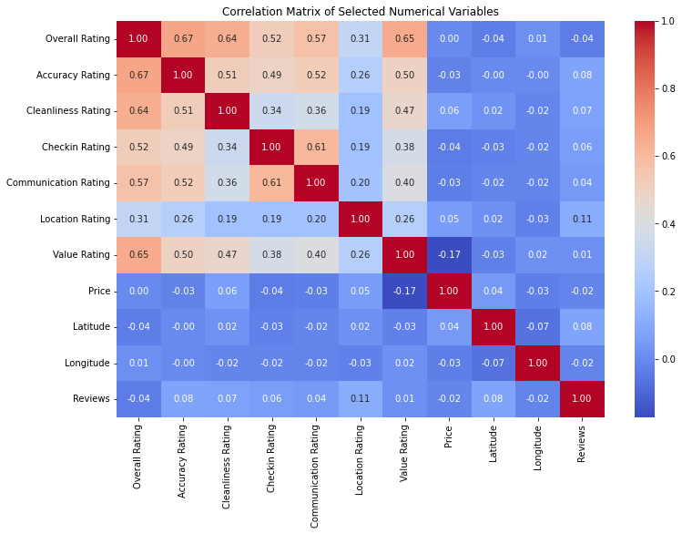

```python
#selecting only numerical columns for correlation analysis
numerical_columns = [
    'Overall Rating', 'Accuracy Rating', 'Cleanliness Rating', 'Checkin Rating',
    'Communication Rating', 'Location Rating', 'Value Rating', 'Price',
    'Latitude', 'Longitude', 'Reviews'
]

#creating a dataframe with only the numerical columns
numerical_data = airbnb_data_encoded[numerical_columns]

#calculating the correlation matrix
correlation_matrix = numerical_data.corr()

#plotting the correlation matrix
plt.figure(figsize=(12, 8))
sns.heatmap(correlation_matrix, annot=True, cmap='coolwarm', fmt='.2f')
plt.title("Correlation Matrix of Selected Numerical Variables")
plt.show()
```

From the graphic we can see that Overall Rating has strong positive correlations with all other rating variables (Accuracy, Cleanliness, Checkin, Communication, and Value), indicating that higher scores in these categories generally contribute to a higher overall rating.

Price shows a very low correlation with all the rating variables, suggesting that the cost of the accommodation is not strongly linked to how guests rate their experience in these aspects.

Geographical Coordinates (Latitude and Longitude) do not show significant correlations with the rating variables, which might imply that the exact location within Berlin is not a major factor in determining the ratings.

We would like to delve further into these findings

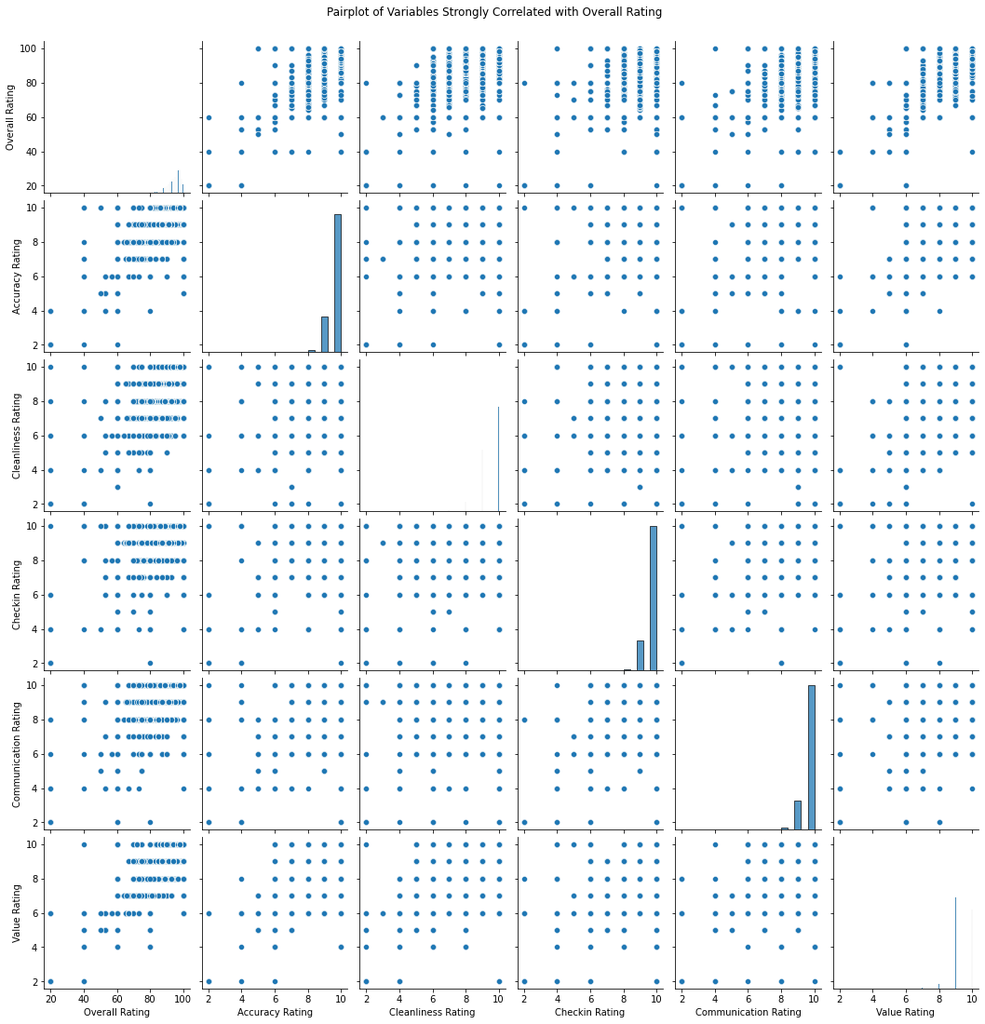

```python
#selecting the columns with strong correlations to 'Overall Rating' for further analysis
#we consider strong correlation to be above 0.5
strong_correlation_columns = correlation_matrix['Overall Rating'][correlation_matrix['Overall Rating'] > 0.5].index.tolist()

#filtering the data for these columns
strong_correlation_data = numerical_data[strong_correlation_columns]

#creating a pairplot to visualize the relationships between 'Overall Rating' and other strongly correlated variables
sns.pairplot(strong_correlation_data)
plt.suptitle("Pairplot of Variables Strongly Correlated with Overall Rating", y=1.02)
plt.show()
```

From the pairplot, we can observe that there are clear linear relationships between 'Overall Rating' and other ratings like 'Value Rating', 'Cleanliness Rating', etc. This indicates that improvements in these specific areas are likely to lead to higher overall satisfaction. For this dataset the distribution of each rating variable shows a concentration of high ratings, suggesting that most customers tend to give high satisfaction scores.

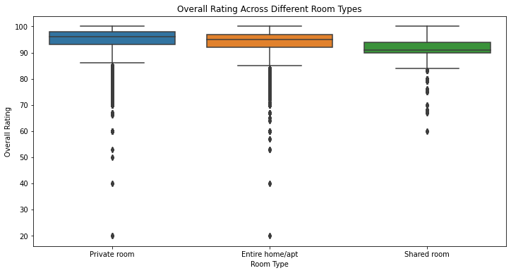

```python
#box plot for 'Overall Rating' across different 'Room Type's
plt.figure(figsize=(12, 6))
sns.boxplot(x='Room Type', y='Overall Rating', data=airbnb_data_encoded)
plt.title('Overall Rating Across Different Room Types')
plt.show()
```